# Predict Bike Sharing Demand with AutoGluon Template

## Step 3: Train a model using AutoGluon’s Tabular Prediction

Requirements:

- We are prediting `count`, so it is the label we are setting.
- Ignore `casual` and `registered` columns as they are also not present in the test dataset.
- Use the `root_mean_squared_error` as the metric to use for evaluation.
- Set a time limit of 10 minutes (600 seconds).
- Use the preset `best_quality` to focus on creating the best model.

```python
# remove casual and registered columns
df_train_cols = train.columns.to_list()
df_train_cols.remove('casual')
df_train_cols.remove('registered')

df_train = train[df_train_cols]
df_train.head()
```

|  | datetime | season | holiday | workingday | weather | temp | atemp | humidity | windspeed | count |
| --- | --- | --- | --- | --- | --- | --- | --- | --- | --- | --- |
| 0 | 2011-01-01 00:00:00 | 1 | 0 | 0 | 1 | 9.84 | 14.395 | 81 | 0.0 | 16 |
| 1 | 2011-01-01 01:00:00 | 1 | 0 | 0 | 1 | 9.02 | 13.635 | 80 | 0.0 | 40 |
| 2 | 2011-01-01 02:00:00 | 1 | 0 | 0 | 1 | 9.02 | 13.635 | 80 | 0.0 | 32 |
| 3 | 2011-01-01 03:00:00 | 1 | 0 | 0 | 1 | 9.84 | 14.395 | 75 | 0.0 | 13 |
| 4 | 2011-01-01 04:00:00 | 1 | 0 | 0 | 1 | 9.84 | 14.395 | 75 | 0.0 | 1 |

```python
predictor = TabularPredictor(
    label='count',
    problem_type='regression',
    eval_metric='root_mean_squared_error'
    ).fit(
    train_data=df_train,
    time_limit=600,
    presets='best_quality',
    )
```

[output not shown]

[output cut: 72 more lines]

```
	-53.6139	 = Validation score   (-root_mean_squared_error)
	7.75s	 = Training   runtime
	0.75s	 = Validation runtime
Fitting model: NeuralNetFastAI_BAG_L2 ... Training model for up to 10.57s of the 10.55s of remaining time.
	Fitting 8 child models (S1F1 - S1F8) | Fitting with ParallelLocalFoldFittingStrategy
	-77.5729	 = Validation score   (-root_mean_squared_error)
	23.59s	 = Training   runtime
	0.85s	 = Validation runtime
Completed 1/20 k-fold bagging repeats ...
Fitting model: WeightedEnsemble_L3 ... Training model for up to 360.0s of the -17.15s of remaining time.
	-52.685	 = Validation score   (-root_mean_squared_error)
	0.42s	 = Training   runtime
	0.0s	 = Validation runtime
AutoGluon training complete, total runtime = 617.61s ... Best model: "WeightedEnsemble_L3"
TabularPredictor saved. To load, use: predictor = TabularPredictor.load("AutogluonModels/ag-20220722_170415/")
```

### Review AutoGluon's training run with ranking of models that did the best.

```python
predictor.fit_summary()
```

```
*** Summary of fit() ***
Estimated performance of each model:
                     model   score_val  pred_time_val    fit_time  pred_time_val_marginal  fit_time_marginal  stack_level  can_infer  fit_order
0      WeightedEnsemble_L3  -52.685043      22.024977  421.564775                0.000872           0.417454            3       True         17
1   RandomForestMSE_BAG_L2  -53.263627      20.865525  397.967331                0.677667          20.825457            2       True         13
2     ExtraTreesMSE_BAG_L2  -53.613935      20.938686  384.891750                0.750828           7.749876            2       True         15
3          LightGBM_BAG_L2  -55.158726      20.595609  392.571988                0.407751          15.430114            2       True         12
4          CatBoost_BAG_L2  -55.733949      20.420263  455.807073                0.232405          78.665199            2       True         14
5        LightGBMXT_BAG_L2  -60.269600      29.769296  419.157287                9.581437          42.015413            2       True         11
6   NeuralNetFastAI_BAG_L2  -77.572855      21.033383  400.731990                0.845525          23.590116            2       True         16
7    KNeighborsDist_BAG_L1  -84.125061       0.105443    0.043398                0.105443           0.043398            1       True          2
8      WeightedEnsemble_L2  -84.125061       0.106495    0.620893                0.001051           0.577495            2       True         10
9    KNeighborsUnif_BAG_L1 -101.546199       0.146152    0.038362                0.146152           0.038362            1       True          1
10  RandomForestMSE_BAG_L1 -116.544294       0.675776    9.135826                0.675776           9.135826            1       True          5
11    ExtraTreesMSE_BAG_L1 -124.588053       0.786606    5.640500                0.786606           5.640500            1       True          7
12         CatBoost_BAG_L1 -130.477488       0.192067  212.543360                0.192067         212.543360            1       True          6
13         LightGBM_BAG_L1 -131.054162       1.880059   17.967937                1.880059          17.967937            1       True          4
14       LightGBMXT_BAG_L1 -131.460909      15.484551   50.759824               15.484551          50.759824            1       True          3
15          XGBoost_BAG_L1 -133.003300       0.191385    8.055574                0.191385           8.055574            1       True          9
16  NeuralNetFastAI_BAG_L1 -136.620267       0.725820   72.957094                0.725820          72.957094            1       True          8
Number of models trained: 17
Types of models trained:
{'StackerEnsembleModel_NNFastAiTabular', 'StackerEnsembleModel_XGBoost', 'StackerEnsembleModel_KNN', 'WeightedEnsembleModel', 'StackerEnsembleModel_CatBoost', 'StackerEnsembleModel_XT', 'StackerEnsembleModel_RF', 'StackerEnsembleModel_LGB'}
Bagging used: True  (with 8 folds)
Multi-layer stack-ensembling used: True  (with 3 levels)
Feature Metadata (Processed):
(raw dtype, special dtypes):
('float', [])                : 3 | ['temp', 'atemp', 'windspeed']
('int', [])                  : 3 | ['season', 'weather', 'humidity']
('int', ['bool'])            : 2 | ['holiday', 'workingday']
('int', ['datetime_as_int']) : 5 | ['datetime', 'datetime.year', 'datetime.month', 'datetime.day', 'datetime.dayofweek']
*** End of fit() summary ***
```

[output not shown]

[output cut: 163 more lines]

[output not shown]

### Create predictions from test dataset

```python
predictions = predictor.predict(test, as_pandas=True)
predictions.head()
```

```
0    22.769447
1    41.009598
2    44.843544
3    48.518120
4    51.608437
Name: count, dtype: float32
```

#### NOTE: Kaggle will reject the submission if we don't set everything to be > 0.

```python
# Describe the `predictions` series to see if there are any negative values
predictions.describe()
```

```
count    6493.000000
mean      100.925575
std        90.329910
min         2.920559
25%        22.129541
50%        62.367935
75%       171.667145
max       363.268372
Name: count, dtype: float64
```

```python
# How many negative values do we have?
(predictions < 0).sum()
```

```
0
```

```python
# Set them to zero
predictions[predictions < 0] = 0
```

### Set predictions to submission dataframe, save, and submit

```python
submission["count"] = predictions
submission.to_csv("submission.csv", index=False)
```

```python
!kaggle competitions submit -c bike-sharing-demand -f submission.csv -m "first raw submission"
```

```
Successfully submitted to Bike Sharing Demand
```

#### View submission via the command line or in the web browser under the competition's page - `My Submissions`

```python
!kaggle competitions submissions -c bike-sharing-demand | tail -n +1 | head -n 6
```

```
fileName        date                 description           status    publicScore  privateScore
--------------  -------------------  --------------------  --------  -----------  ------------
submission.csv  2022-07-22 18:07:12  first raw submission  complete  1.80346      1.80346
```

#### Initial score of 1.80346

## Step 4: Exploratory Data Analysis and Creating an additional feature

- Any additional feature will do, but a great suggestion would be to separate out the datetime into hour, day, or month parts.

```
array([[<AxesSubplot:title={'center':'datetime'}>,
        <AxesSubplot:title={'center':'season'}>,
        <AxesSubplot:title={'center':'holiday'}>],
       [<AxesSubplot:title={'center':'workingday'}>,
        <AxesSubplot:title={'center':'weather'}>,
        <AxesSubplot:title={'center':'temp'}>],
       [<AxesSubplot:title={'center':'atemp'}>,
        <AxesSubplot:title={'center':'humidity'}>,
        <AxesSubplot:title={'center':'windspeed'}>],
       [<AxesSubplot:title={'center':'casual'}>,
        <AxesSubplot:title={'center':'registered'}>,
        <AxesSubplot:title={'center':'count'}>]], dtype=object)
```

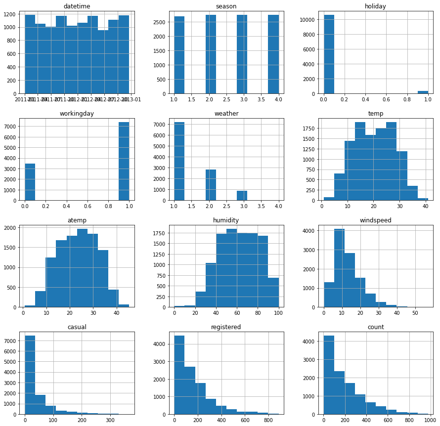

```python
# Create a histogram of all features to show the distribution of each one relative to the data. This is part of the exploritory data analysis
train.hist(figsize=(15,15))
```

## Examining day time statistics

```python
# Examining years available
print("years in training data : ", train.datetime.dt.year.unique())
print("years in test data : ", test.datetime.dt.year.unique())
print("####")

# Examining months available
print("Months available in training data : ", train.datetime.dt.month.unique())
print("Months available in test data : ", test.datetime.dt.month.unique())
print("####")

# Examining days available
print("Days available in training data : ", train.datetime.dt.day.unique())
print("Days available in test data : ", test.datetime.dt.day.unique())
print("####")

# Examining hours available
print("Hours available in training data : ", train.datetime.dt.hour.unique())
print("Hours available in test data : ", test.datetime.dt.hour.unique())
print("####")
```

```
years in training data :  [2011 2012]
years in test data :  [2011 2012]
####
Months available in training data :  [ 1  2  3  4  5  6  7  8  9 10 11 12]
Months available in test data :  [ 1  2  3  4  5  6  7  8  9 10 11 12]
####
Days available in training data :  [ 1  2  3  4  5  6  7  8  9 10 11 12 13 14 15 16 17 18 19]
Days available in test data :  [20 21 22 23 24 25 26 27 28 29 30 31]
####
Hours available in training data :  [ 0  1  2  3  4  5  6  7  8  9 10 11 12 13 14 15 16 17 18 19 20 21 22 23]
Hours available in test data :  [ 0  1  2  3  4  5  6  7  8  9 10 11 12 13 14 15 16 17 18 19 20 21 22 23]
####
```

```python
# create a new feature
train['hour'] = train.datetime.dt.hour
test['hour'] = test.datetime.dt.hour
```

## Make category types for these so models know they are not just numbers

- AutoGluon originally sees these as ints, but in reality they are int representations of a category.
- Setting the dtype to category will classify these as categories in AutoGluon.

```python
train["season"] = train.season.astype('category')
train["weather"] = train.weather.astype('category')
test["season"] = test.season.astype('category')
test["weather"] = test.weather.astype('category')
```

```python
# View are new feature
train.head()
```

|  | datetime | season | holiday | workingday | weather | temp | atemp | humidity | windspeed | casual | registered | count | hour |
| --- | --- | --- | --- | --- | --- | --- | --- | --- | --- | --- | --- | --- | --- |
| 0 | 2011-01-01 00:00:00 | 1 | 0 | 0 | 1 | 9.84 | 14.395 | 81 | 0.0 | 3 | 13 | 16 | 0 |
| 1 | 2011-01-01 01:00:00 | 1 | 0 | 0 | 1 | 9.02 | 13.635 | 80 | 0.0 | 8 | 32 | 40 | 1 |
| 2 | 2011-01-01 02:00:00 | 1 | 0 | 0 | 1 | 9.02 | 13.635 | 80 | 0.0 | 5 | 27 | 32 | 2 |
| 3 | 2011-01-01 03:00:00 | 1 | 0 | 0 | 1 | 9.84 | 14.395 | 75 | 0.0 | 3 | 10 | 13 | 3 |
| 4 | 2011-01-01 04:00:00 | 1 | 0 | 0 | 1 | 9.84 | 14.395 | 75 | 0.0 | 0 | 1 | 1 | 4 |

```
array([[<AxesSubplot:title={'center':'datetime'}>,
        <AxesSubplot:title={'center':'holiday'}>,
        <AxesSubplot:title={'center':'workingday'}>],
       [<AxesSubplot:title={'center':'temp'}>,
        <AxesSubplot:title={'center':'atemp'}>,
        <AxesSubplot:title={'center':'humidity'}>],
       [<AxesSubplot:title={'center':'windspeed'}>,
        <AxesSubplot:title={'center':'casual'}>,
        <AxesSubplot:title={'center':'registered'}>],
       [<AxesSubplot:title={'center':'count'}>,
        <AxesSubplot:title={'center':'hour'}>, <AxesSubplot:>]],
      dtype=object)
```

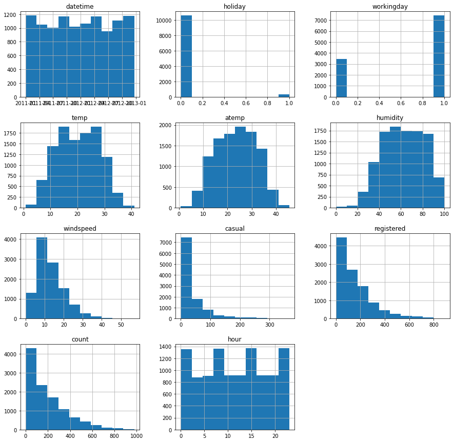

```python
# View histogram of all features again now with the hour feature
train.hist(figsize=(15,15))
```

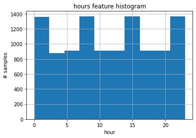

```python
# hour feature histogram
ax = train['hour'].hist()
ax.set_xlabel('hour')
ax.set_ylabel('# samples')
ax.set_title('hours feature histogram')
fig = ax.get_figure()
fig.savefig('img/hour_feature_hist.png')
```

## Step 5: Rerun the model with the same settings as before, just with more features

```python
# remove casual and registered columns since they are not recorded in the testset
df_train_new_features_cols = train.columns.to_list()
df_train_new_features_cols.remove('casual')
df_train_new_features_cols.remove('registered')

df_train_new_features = train[df_train_new_features_cols]
df_train_new_features.head()
```

|  | datetime | season | holiday | workingday | weather | temp | atemp | humidity | windspeed | count | hour |
| --- | --- | --- | --- | --- | --- | --- | --- | --- | --- | --- | --- |
| 0 | 2011-01-01 00:00:00 | 1 | 0 | 0 | 1 | 9.84 | 14.395 | 81 | 0.0 | 16 | 0 |
| 1 | 2011-01-01 01:00:00 | 1 | 0 | 0 | 1 | 9.02 | 13.635 | 80 | 0.0 | 40 | 1 |
| 2 | 2011-01-01 02:00:00 | 1 | 0 | 0 | 1 | 9.02 | 13.635 | 80 | 0.0 | 32 | 2 |
| 3 | 2011-01-01 03:00:00 | 1 | 0 | 0 | 1 | 9.84 | 14.395 | 75 | 0.0 | 13 | 3 |
| 4 | 2011-01-01 04:00:00 | 1 | 0 | 0 | 1 | 9.84 | 14.395 | 75 | 0.0 | 1 | 4 |

```python
predictor_new_features = TabularPredictor(
    label='count',
    problem_type='regression',
    eval_metric='root_mean_squared_error'
    ).fit(
    train_data=df_train_new_features,
    time_limit=600,
    presets='best_quality',
    )
```

[output not shown]

[output cut: 71 more lines]

```
	-31.3935	 = Validation score   (-root_mean_squared_error)
	5.03s	 = Training   runtime
	0.61s	 = Validation runtime
Fitting model: NeuralNetFastAI_BAG_L2 ... Training model for up to 18.74s of the 18.73s of remaining time.
	Fitting 8 child models (S1F1 - S1F8) | Fitting with ParallelLocalFoldFittingStrategy
	-31.877	 = Validation score   (-root_mean_squared_error)
	24.12s	 = Training   runtime
	0.64s	 = Validation runtime
Completed 1/20 k-fold bagging repeats ...
Fitting model: WeightedEnsemble_L3 ... Training model for up to 360.0s of the -8.54s of remaining time.
	-30.1371	 = Validation score   (-root_mean_squared_error)
	0.44s	 = Training   runtime
	0.0s	 = Validation runtime
AutoGluon training complete, total runtime = 609.04s ... Best model: "WeightedEnsemble_L3"
TabularPredictor saved. To load, use: predictor = TabularPredictor.load("AutogluonModels/ag-20220723_100545/")
```

```python
predictor_new_features.fit_summary()
```

```
*** Summary of fit() ***
Estimated performance of each model:
                     model   score_val  pred_time_val    fit_time  pred_time_val_marginal  fit_time_marginal  stack_level  can_infer  fit_order
0      WeightedEnsemble_L3  -30.137145      35.564555  564.194422                0.001191           0.444415            3       True         16
1          CatBoost_BAG_L2  -30.396360      32.180990  490.780134                0.216519         110.807671            2       True         13
2          LightGBM_BAG_L2  -30.636003      32.457725  393.230914                0.493254          13.258451            2       True         11
3        LightGBMXT_BAG_L2  -30.983894      33.623777  397.794642                1.659306          17.822179            2       True         10
4     ExtraTreesMSE_BAG_L2  -31.393519      32.575102  384.999219                0.610631           5.026755            2       True         14
5   RandomForestMSE_BAG_L2  -31.611381      32.552560  397.743890                0.588088          17.771426            2       True         12
6   NeuralNetFastAI_BAG_L2  -31.876962      32.606197  404.090281                0.641726          24.117817            2       True         15
7      WeightedEnsemble_L2  -32.077964      30.854712  330.002484                0.000772           0.461355            2       True          9
8          CatBoost_BAG_L1  -33.476810       0.338120  241.279289                0.338120         241.279289            1       True          6
9          LightGBM_BAG_L1  -33.919639       5.627284   26.382168                5.627284          26.382168            1       True          4
10       LightGBMXT_BAG_L1  -34.457274      24.259450   54.720497               24.259450          54.720497            1       True          3
11    ExtraTreesMSE_BAG_L1  -38.323016       0.510248    4.185575                0.510248           4.185575            1       True          7
12  RandomForestMSE_BAG_L1  -38.445932       0.524852    7.123883                0.524852           7.123883            1       True          5
13  NeuralNetFastAI_BAG_L1  -52.648813       0.492928   46.197454                0.492928          46.197454            1       True          8
14   KNeighborsDist_BAG_L1  -84.125061       0.104233    0.035292                0.104233           0.035292            1       True          2
15   KNeighborsUnif_BAG_L1 -101.546199       0.107355    0.048305                0.107355           0.048305            1       True          1
Number of models trained: 16
Types of models trained:
{'StackerEnsembleModel_RF', 'StackerEnsembleModel_CatBoost', 'StackerEnsembleModel_LGB', 'StackerEnsembleModel_NNFastAiTabular', 'StackerEnsembleModel_XT', 'WeightedEnsembleModel', 'StackerEnsembleModel_KNN'}
Bagging used: True  (with 8 folds)
Multi-layer stack-ensembling used: True  (with 3 levels)
Feature Metadata (Processed):
(raw dtype, special dtypes):
('category', [])             : 2 | ['season', 'weather']
('float', [])                : 3 | ['temp', 'atemp', 'windspeed']
('int', [])                  : 2 | ['humidity', 'hour']
('int', ['bool'])            : 2 | ['holiday', 'workingday']
('int', ['datetime_as_int']) : 5 | ['datetime', 'datetime.year', 'datetime.month', 'datetime.day', 'datetime.dayofweek']
*** End of fit() summary ***
```

[output not shown]

[output cut: 151 more lines]

[output not shown]

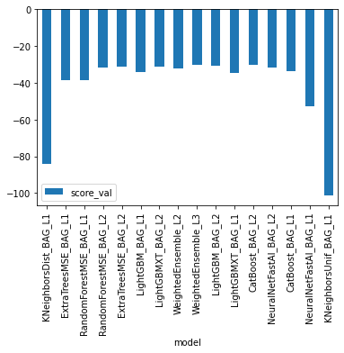

```python
predictor_new_features.leaderboard(df_train_new_features, silent=True).plot(kind='bar', x='model', y='score_val')
```

```python
# Remember to set all negative values to zero
predictions_new_features = predictor_new_features.predict(test, as_pandas=True)
```

```python
(predictions_new_features < 0).sum()
```

```
0
```

```python
predictions_new_features[predictions_new_features < 0] = 0
```

```python
# Same submitting predictions
submission_new_features = pd.read_csv('submission.csv')
submission_new_features["count"] = predictions_new_features
submission_new_features.to_csv("submission_new_features.csv", index=False)
```

```python
!kaggle competitions submit -c bike-sharing-demand -f submission_new_features.csv -m "new features"
```

```
Successfully submitted to Bike Sharing Demand
```

```python
!kaggle competitions submissions -c bike-sharing-demand | tail -n +1 | head -n 6
```

```
fileName                     date                 description           status    publicScore  privateScore
---------------------------  -------------------  --------------------  --------  -----------  ------------
submission_new_features.csv  2022-07-23 11:33:59  new features          complete  0.69969      0.69969
submission.csv               2022-07-22 18:07:12  first raw submission  complete  1.80346      1.80346
```

#### New Score of 0.69969

## Step 6: Hyper parameter optimization

- There are many options for hyper parameter optimization.
- Options are to change the AutoGluon higher level parameters or the individual model hyperparameters.
- The hyperparameters of the models themselves that are in AutoGluon. Those need the `hyperparameter` and `hyperparameter_tune_kwargs` arguments.

```python
import autogluon.core as ag
# hyperparameter settings
gbm_options = {
    'num_boost_round' : ag.space.Int(lower=100, upper=500, default=100),
    'num_leaves' : ag.space.Int(lower=6, upper=10),
    'learning_rate' : ag.space.Real(lower=0.01, upper=0.3, log=True)
}


cat_options = {
    'iterations' : 100,
    'learning_rate' : ag.space.Real(lower=0.01, upper=0.3, log=True),
    'depth' : ag.space.Int(lower=6, upper=10)
}
xgb_options = {
    'n_estimators' : ag.space.Int(lower=100, upper=500, default=100),
    'max_depth' : ag.space.Int(lower=6, upper=10, default=6),
    'eta' : ag.space.Real(lower=0.01, upper=0.3, log=True)
}
```

```python
# Choosing specific hyperparameter options
# Models : GBM, CAT, XGB, RF, XT, KNN, LR, NN_MXNET, NN_TORCH
hyperparameters = {
    'XGB' : xgb_options,
    'GBM' : gbm_options,
    'CAT' : cat_options
}

num_trials = 5
search_strategy = 'random'

hyperparameter_tune_kwargs = {
    'num_trials' : num_trials,
    'scheduler' : 'local',
    'searcher' : search_strategy
}
```

```python
predictor_new_hpo = TabularPredictor(
    label='count',
    problem_type='regression',
    eval_metric='root_mean_squared_error',
    path='AutogluonModels/xgb_gbm_cat_tuning_v1'
    ).fit(
    train_data=df_train_new_features,
    time_limit=600,
    presets='best_quality',
    hyperparameters=hyperparameters,
    hyperparameter_tune_kwargs=hyperparameter_tune_kwargs,
    )
```

[output not shown]

```
Fitted model: LightGBM_BAG_L1/T1 ...
	-122.0059	 = Validation score   (-root_mean_squared_error)
	1.27s	 = Training   runtime
	0.07s	 = Validation runtime
Fitted model: LightGBM_BAG_L1/T2 ...
	-36.9968	 = Validation score   (-root_mean_squared_error)
	0.41s	 = Training   runtime
	0.01s	 = Validation runtime
Fitted model: LightGBM_BAG_L1/T3 ...
	-43.1295	 = Validation score   (-root_mean_squared_error)
	0.33s	 = Training   runtime
	0.01s	 = Validation runtime
Fitted model: LightGBM_BAG_L1/T4 ...
	-72.9824	 = Validation score   (-root_mean_squared_error)
	0.18s	 = Training   runtime
	0.01s	 = Validation runtime
Fitted model: LightGBM_BAG_L1/T5 ...
	-35.4935	 = Validation score   (-root_mean_squared_error)
	0.32s	 = Training   runtime
	0.01s	 = Validation runtime
Hyperparameter tuning model: CatBoost_BAG_L1 ... Tuning model for up to 14.99s of the 596.79s of remaining time.
```

```
Fitted model: CatBoost_BAG_L1/T1 ...
	-112.5436	 = Validation score   (-root_mean_squared_error)
	0.62s	 = Training   runtime
	0.01s	 = Validation runtime
Fitted model: CatBoost_BAG_L1/T2 ...
	-34.3219	 = Validation score   (-root_mean_squared_error)
	1.3s	 = Training   runtime
	0.01s	 = Validation runtime
Fitted model: CatBoost_BAG_L1/T3 ...
	-45.1337	 = Validation score   (-root_mean_squared_error)
	0.84s	 = Training   runtime
	0.01s	 = Validation runtime
Fitted model: CatBoost_BAG_L1/T4 ...
	-36.2087	 = Validation score   (-root_mean_squared_error)
	0.56s	 = Training   runtime
	0.01s	 = Validation runtime
Fitted model: CatBoost_BAG_L1/T5 ...
	-54.2314	 = Validation score   (-root_mean_squared_error)
	0.41s	 = Training   runtime
	0.01s	 = Validation runtime
Hyperparameter tuning model: XGBoost_BAG_L1 ... Tuning model for up to 14.99s of the 592.82s of remaining time.
```

[output not shown]

[output cut: 47 more lines]

```
	-35.1624	 = Validation score   (-root_mean_squared_error)
	13.3s	 = Training   runtime
	0.49s	 = Validation runtime
Fitting model: XGBoost_BAG_L1/T5 ... Training model for up to 216.84s of the 416.88s of remaining time.
	Fitting 7 child models (S1F2 - S1F8) | Fitting with ParallelLocalFoldFittingStrategy
	-35.6798	 = Validation score   (-root_mean_squared_error)
	17.43s	 = Training   runtime
	0.84s	 = Validation runtime
Completed 1/20 k-fold bagging repeats ...
Fitting model: WeightedEnsemble_L2 ... Training model for up to 360.0s of the 398.32s of remaining time.
	-34.4166	 = Validation score   (-root_mean_squared_error)
	0.86s	 = Training   runtime
	0.0s	 = Validation runtime
Fitting 3 L2 models ...
Hyperparameter tuning model: LightGBM_BAG_L2 ... Tuning model for up to 14.9s of the 397.42s of remaining time.
```

```
Fitted model: LightGBM_BAG_L2/T1 ...
	-76.7751	 = Validation score   (-root_mean_squared_error)
	0.47s	 = Training   runtime
	0.01s	 = Validation runtime
Fitted model: LightGBM_BAG_L2/T2 ...
	-37.3484	 = Validation score   (-root_mean_squared_error)
	0.47s	 = Training   runtime
	0.01s	 = Validation runtime
Fitted model: LightGBM_BAG_L2/T3 ...
	-37.4946	 = Validation score   (-root_mean_squared_error)
	0.63s	 = Training   runtime
	0.01s	 = Validation runtime
Fitted model: LightGBM_BAG_L2/T4 ...
	-37.5186	 = Validation score   (-root_mean_squared_error)
	0.35s	 = Training   runtime
	0.01s	 = Validation runtime
Fitted model: LightGBM_BAG_L2/T5 ...
	-37.2552	 = Validation score   (-root_mean_squared_error)
	0.45s	 = Training   runtime
	0.01s	 = Validation runtime
Hyperparameter tuning model: CatBoost_BAG_L2 ... Tuning model for up to 14.9s of the 394.68s of remaining time.
```

```
	Stopping HPO to satisfy time limit...
Fitted model: CatBoost_BAG_L2/T1 ...
	-78.1653	 = Validation score   (-root_mean_squared_error)
	0.89s	 = Training   runtime
	0.01s	 = Validation runtime
Fitted model: CatBoost_BAG_L2/T2 ...
	-38.1135	 = Validation score   (-root_mean_squared_error)
	5.74s	 = Training   runtime
	0.01s	 = Validation runtime
Fitted model: CatBoost_BAG_L2/T3 ...
	-38.5035	 = Validation score   (-root_mean_squared_error)
	3.52s	 = Training   runtime
	0.01s	 = Validation runtime
Hyperparameter tuning model: XGBoost_BAG_L2 ... Tuning model for up to 14.9s of the 384.29s of remaining time.
```

[output not shown]

[output cut: 38 more lines]

```
	-34.5209	 = Validation score   (-root_mean_squared_error)
	22.02s	 = Training   runtime
	0.33s	 = Validation runtime
Fitting model: XGBoost_BAG_L2/T5 ... Training model for up to 154.64s of the 154.62s of remaining time.
	Fitting 7 child models (S1F2 - S1F8) | Fitting with ParallelLocalFoldFittingStrategy
	-34.3135	 = Validation score   (-root_mean_squared_error)
	28.93s	 = Training   runtime
	0.4s	 = Validation runtime
Completed 1/20 k-fold bagging repeats ...
Fitting model: WeightedEnsemble_L3 ... Training model for up to 360.0s of the 124.95s of remaining time.
	-34.0572	 = Validation score   (-root_mean_squared_error)
	0.78s	 = Training   runtime
	0.0s	 = Validation runtime
AutoGluon training complete, total runtime = 475.86s ... Best model: "WeightedEnsemble_L3"
TabularPredictor saved. To load, use: predictor = TabularPredictor.load("AutogluonModels/xgb_gbm_cat_tuning_v1/")
```

```python
predictor_new_hpo.fit_summary(verbosity=3)
```

```
*** Summary of fit() ***
Estimated performance of each model:
                  model   score_val  pred_time_val    fit_time  pred_time_val_marginal  fit_time_marginal  stack_level  can_infer  fit_order
0   WeightedEnsemble_L3  -34.057244       6.348961  311.016289                0.001106           0.782345            3       True         30
1     XGBoost_BAG_L2/T3  -34.286425       4.954254  164.987384                0.357588          22.998391            2       True         27
2     XGBoost_BAG_L2/T5  -34.313504       4.997365  170.917452                0.400699          28.928459            2       True         29
3    LightGBM_BAG_L2/T3  -34.368795       4.723312  151.042335                0.126646           9.053343            2       True         19
4     XGBoost_BAG_L2/T2  -34.384069       4.900711  161.070759                0.304046          19.081767            2       True         26
5   WeightedEnsemble_L2  -34.416649       2.350209   63.737813                0.001028           0.855778            2       True         16
6    LightGBM_BAG_L2/T2  -34.472362       4.700583  150.564948                0.103918           8.575956            2       True         18
7    LightGBM_BAG_L2/T5  -34.477298       4.693503  150.213981                0.096837           8.224989            2       True         21
8    LightGBM_BAG_L2/T4  -34.478955       4.709323  149.660562                0.112658           7.671569            2       True         20
9     XGBoost_BAG_L2/T4  -34.520919       4.921695  164.004920                0.325029          22.015928            2       True         28
10    XGBoost_BAG_L2/T1  -34.848284       4.827082  150.696827                0.230416           8.707835            2       True         25
11   CatBoost_BAG_L2/T3  -35.118526       4.769622  170.171618                0.172956          28.182626            2       True         24
12    XGBoost_BAG_L1/T4  -35.162359       0.485035   13.302318                0.485035          13.302318            1       True         14
13   CatBoost_BAG_L2/T2  -35.173122       4.785164  185.188414                0.188498          43.199422            2       True         23
14    XGBoost_BAG_L1/T2  -35.360442       0.471930   11.648892                0.471930          11.648892            1       True         12
15    XGBoost_BAG_L1/T5  -35.679769       0.840477   17.432415                0.840477          17.432415            1       True         15
16   CatBoost_BAG_L1/T2  -36.060110       0.181465   12.883185                0.181465          12.883185            1       True          7
17    XGBoost_BAG_L1/T3  -36.207496       0.516670   12.869178                0.516670          12.869178            1       True         13
18   CatBoost_BAG_L1/T4  -37.211233       0.164535    8.745189                0.164535           8.745189            1       True          9
19   LightGBM_BAG_L1/T5  -37.499402       0.370275    7.615225                0.370275           7.615225            1       True          5
20    XGBoost_BAG_L1/T1  -38.075542       0.183297    5.570019                0.183297           5.570019            1       True         11
21   LightGBM_BAG_L1/T2  -39.175818       0.283948    7.033527                0.283948           7.033527            1       True          2
22   LightGBM_BAG_L1/T3  -44.466449       0.379462    7.044823                0.379462           7.044823            1       True          3
23   CatBoost_BAG_L1/T3  -46.957733       0.131243   10.111333                0.131243          10.111333            1       True          8
24   CatBoost_BAG_L1/T5  -55.346157       0.155049    6.862860                0.155049           6.862860            1       True         10
25   LightGBM_BAG_L1/T4  -73.801220       0.124614    6.756800                0.124614           6.756800            1       True          4
26   LightGBM_BAG_L2/T1  -76.852149       4.702094  149.690574                0.105428           7.701582            2       True         17
27   CatBoost_BAG_L2/T1  -77.958483       4.701531  152.092612                0.104865          10.103619            2       True         22
28   CatBoost_BAG_L1/T1 -112.903265       0.156651    7.039407                0.156651           7.039407            1       True          6
29   LightGBM_BAG_L1/T1 -123.331068       0.152013    7.073822                0.152013           7.073822            1       True          1
Number of models trained: 30
Types of models trained:
{'StackerEnsembleModel_XGBoost', 'StackerEnsembleModel_LGB', 'WeightedEnsembleModel', 'StackerEnsembleModel_CatBoost'}
Bagging used: True  (with 8 folds)
Multi-layer stack-ensembling used: True  (with 3 levels)
Feature Metadata (Processed):
(raw dtype, special dtypes):
('category', [])             : 2 | ['season', 'weather']
('float', [])                : 3 | ['temp', 'atemp', 'windspeed']
('int', [])                  : 2 | ['humidity', 'hour']
('int', ['bool'])            : 2 | ['holiday', 'workingday']
('int', ['datetime_as_int']) : 5 | ['datetime', 'datetime.year', 'datetime.month', 'datetime.day', 'datetime.dayofweek']
*** End of fit() summary ***
```

[output not shown]

[output cut: 313 more lines]

[output not shown]

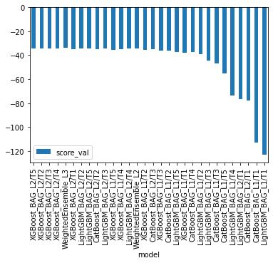

```python
predictor_new_hpo.leaderboard(df_train_new_features, silent=True).plot(kind='bar', x='model', y='score_val')
```

```python
# Remember to set all negative values to zero
predictions_new_hpo = predictor_new_hpo.predict(test, as_pandas=True)
```

```python
(predictions_new_hpo < 0).sum()
```

```
0
```

```python
predictions_new_hpo[predictions_new_hpo < 0] = 0
```

```python
# Same submitting predictions
submission_new_hpo = submission
submission_new_hpo["count"] = predictions_new_hpo
# # testing rounding predictions
# submission_new_hpo['count'] = submission_new_hpo["count"].astype('int64')
submission_new_hpo.to_csv("submission_new_hpo_cat_gbm_xgb_2.csv", index=False)
```

```python
!kaggle competitions submit -c bike-sharing-demand -f submission_new_hpo_cat_gbm_xgb_2.csv -m "new features with hyperparameters cat xgb gbm 2 rounded"
```

```
Successfully submitted to Bike Sharing Demand
```

```python
!kaggle competitions submissions -c bike-sharing-demand | tail -n +1 | head -n 6
```

```
fileName                              date                 description                                              status    publicScore  privateScore
------------------------------------  -------------------  -------------------------------------------------------  --------  -----------  ------------
submission_new_hpo_cat_gbm_xgb_2.csv  2022-07-25 17:26:03  new features with hyperparameters cat xgb gbm 2 rounded  complete  0.45160      0.45160
submission_new_hpo_cat_gbm_xgb_2.csv  2022-07-25 17:17:24  new features with hyperparameters cat xgb gbm 2          complete  0.45605      0.45605
submission_new_hpo_cat_gbm_xgb.csv    2022-07-25 12:47:00  new features with hyperparameters cat xgb gbm            complete  0.51936      0.51936
submission_new_hpo.csv                2022-07-23 18:10:22  new features with hyperparameters                        complete  0.51826      0.51826
```

## Step 7: Write a Report

### Refer to the markdown file for the full report

### Creating plots and table for report

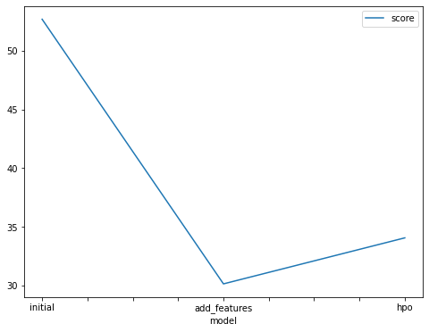

```python
# Taking the top model score from each training run and creating a line plot to show improvement
# You can create these in the notebook and save them to PNG or use some other tool (e.g. google sheets, excel)
fig = pd.DataFrame(
    {
        "model": ["initial", "add_features", "hpo"],
        "score": [52.685043 , 30.137145 , 34.057244]
    }
).plot(x="model", y="score", figsize=(8, 6)).get_figure()
fig.savefig('model_train_score.png')
```

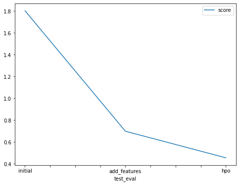

```python
# Take the 3 kaggle scores and creating a line plot to show improvement
fig = pd.DataFrame(
    {
        "test_eval": ["initial", "add_features", "hpo"],
        "score": [1.80346, 0.69969, 0.45605]
    }
).plot(x="test_eval", y="score", figsize=(8, 6)).get_figure()
fig.savefig('model_test_score.png')
```

### Hyperparameter table

```python
# The 3 hyperparameters we tuned with the kaggle score as the result
table_df = pd.DataFrame({
    "model": ["initial", "add_features", "hpo"],
    "hpo1": [
        'default_vals',
        'default_vals',
        'GBM (Light gradient boosting) : num_boost_round: [lower=100, upper=500], num_leaves:[lower=6, upper=10], learning_rate:[lower=0.01, upper=0.3, log scale], applying random search with 5 trials'
        ],
    "hpo2": [
        'default_vals',
        'default_vals',
        'XGB (XGBoost): n_estimators : [lower=100, upper=500], max_depth : [lower=6, upper=10], eta (learning_rate) : [lower=0.01, upper=0.3, log scale] applying random search with 5 trials'
        ],
    "hpo3": [
        'default_vals',
        'default_vals',
        'CAT (CATBoost) : iterations : 100, depth : [lower=6, upper=10], learning_rate  : [lower=0.01, upper=0.3, log scale] applying random search with 5 trials'
    ],
    "score": [1.80346, 0.69969, 0.45605]
})

table_df
```

|  | model | hpo1 | hpo2 | hpo3 | score |
| --- | --- | --- | --- | --- | --- |
| 0 | initial | default_vals | default_vals | default_vals | 1.80346 |
| 1 | add_features | default_vals | default_vals | default_vals | 0.69969 |
| 2 | hpo | GBM (Light gradient boosting) : num_boost_roun... | XGB (XGBoost): n_estimators : [lower=100, uppe... | CAT (CATBoost) : iterations : 100, depth : [lo... | 0.45605 |

```python
print(table_df.to_markdown())
```

[output not shown]